# Milestone Report

Shrishti Kaushik

09/07/2020

## Introduction

The objective of this report is just to display that i have understood the data and i am on track to create my prediction algorithm. Through this report i explain exploratory data analysis and my approach for the eventual app and algorithm. I have made use of tables and plots to illustrate important summaries of the data set. The motivation for this project is to:  
1. Demonstrate that I’ve downloaded the data and have successfully loaded it in R  
2. Create a basic report of summary statistics about the data sets.  
3. Report any interesting findings that you amassed so far.  
4. Get feedback on my plans for creating a prediction algorithm and Shiny app.

### Task 0 Understanding The Problem

#### Loading the required libraries:

```r
library(tm)
library(slam)
library(tokenizers)
library(plotly)
library(wordcloud)
library(RColorBrewer)
```

#### Getting the data:

```r
engblog<-file("C:\\Users\\Shrishti\\Downloads\\Coursera-SwiftKey\\final\\en_US\\en_US.blogs.txt","r")
enb<-readLines(engblog,encoding="UTF-8")
close.connection(engblog)
engnews<-file("C:\\Users\\Shrishti\\Downloads\\Coursera-SwiftKey\\final\\en_US\\en_US.news.txt","r")
enn<-readLines(engnews,encoding="UTF-8")
close.connection(engnews)
engtwitter<-file("C:\\Users\\Shrishti\\Downloads\\Coursera-SwiftKey\\final\\en_US\\en_US.twitter.txt","r")
ent<-readLines(engtwitter,encoding="UTF-8")
close.connection(engtwitter)
```

#### Basic summary of the data:

```r
df<-data.frame(files=c("Blogs","News","Twitter"),length=c(length(enb),length(enn),length(ent)))
df
```

```
##     files  length
## 1   Blogs  899288
## 2    News   77259
## 3 Twitter 2360148
```

#### Understanding the data:

As the datset is fairly large, instead of using the entire dataset we can use a sample of the dataset. Therfore we perform sampling on each of the three files. we’ll take a total of 90,000 lines and since twitter has the most number of elements we’ll take 45,000 from there and 30,000 from blogs and 15,000 from news.

```r
set.seed(123)
sam_data<-sample(ent,45000)
sam_data<-c(sam_data,sample(enb,30000,replace = FALSE))
sam_data<-c(sam_data,sample(enn,15000,replace=FALSE))
```

### Task 1 Getting and Cleaning The Data

For efficient pre-processing and processing of the dataset, I have first culminated the dataset from all the three files into a “Corpus”. Once the corpus has been created, I need to clean the data next. For cleaning the data, i have made use of the “tm” package in R. Cleaning of the datset involves:  
* Converting to lower case  
* Removing space and special characters  
* Removing stopwords (example: is, it, he, have etc.)  
* Removing any extra whitespace  
* Removing Numbers  
* Removing punctuations

```r
sam_data_cor<-Corpus(VectorSource(sam_data))

mydata <- tm_map(sam_data_cor, content_transformer(tolower))
removeNumPunct <- function(x) gsub("[^[:alpha:][:space:]]*", "", x)
mydata <- tm_map(mydata, content_transformer(removeNumPunct))
mydata <- tm_map(mydata, removeWords, stopwords("english"))
mydata <- tm_map(mydata, stripWhitespace)
mydata <- tm_map(mydata, removeNumbers)
mydata <- tm_map(mydata, removePunctuation)
```

#### Tokenization:

To perform tokenization, I have made use of the “tokenizers” package. I have defined three functions each for tokeninzing into words, sentences and characters.

```r
tokenwords<-function(x){
  y<-tokenize_words(x)
  yu<-unlist(y,recursive = FALSE)
  yu
}
tokesentence<-function(x){
  y<-tokenize_sentences(x)
  yu<-unlist(y,recursive = FALSE)
  yu
}
tokenchar<-function(x){
  y<-tokenize_characters(x)
  yu<-unlist(y,recursive = FALSE)
  yu
}
```

After creating the functions, each file has then been passed to the functions to perform tokenization. As it can be observed, the dataframe thus created shows the number of words, characters and sentences in each of the files.

```r
df2<-data.frame(Source=c("Blogs","Twitter","News"),Characters=c(length(tokenchar(sample(enb,30000))),
                                                                length(tokenchar(sample(ent,45000))),
                                                                length(tokenchar(sample(enn,15000)))),
                Words=c(length(tokenwords(sample(enb,30000))),
                        length(tokenwords(sample(ent,45000))),
                        length(tokenwords(sample(enn,15000)))),
                Sentences=c(length(tokesentence(sample(enb,30000))),
                            length(tokesentence(sample(ent,45000))),
                            length(tokesentence(sample(enn,15000)))))
df2
```

```
##    Source Characters   Words Sentences
## 1   Blogs    5500653 1264625     78664
## 2 Twitter    2401648  575456     72145
## 3    News    2432522  518488     30305
```

#### Profanity Filtering

The last thing that needs to be accomplished for task 1 is profanity filtering. To remove profanity from the text, I have used this [link](https://github.com/LDNOOBW/List-of-Dirty-Naughty-Obscene-and-Otherwise-Bad-Words/blob/master/en) to obtain a list of the badwords. Then using tm_map function I have successfully removed bad words from the text.

```r
badwords<-file("C:\\Users\\Shrishti\\Downloads\\Coursera-SwiftKey\\final\\badwords.txt","r")
profan<-readLines(badwords)
close.connection(badwords)
sd2<-tm_map(mydata,removeWords,profan)
```

Fianlly once the entire dataset is cleaned, it is then converted to a “Document Term Matrix” for further analysis as a part of Task2.

```r
sam_data_tdm22<-DocumentTermMatrix(sd2)
```

### Task 2 Exploratory Data Analysis

Here are the top 20 most frequent words:

```r
csd2<-col_sums(sam_data_tdm22) ## slam package
csd_sort<-sort(csd2,decreasing=TRUE)
Words=names(csd_sort[1:20])
Frequency=csd_sort[1:20]
data1 <- data.frame(Words, Frequency, stringsAsFactors = FALSE)
data1$Words <- factor(data1$Words, levels = unique(data1$Words)[order(data1$Frequency, decreasing = FALSE)])
first=plot_ly(data1,x=~Frequency,y=~Words,type = "bar")%>%layout(title="Top 20 Most Frequent Words")
first
```

[interactive chart not shown]

To create a set of two words, i ahve used the tokenize_ngrams fucntion. Here are the top 10 most frequent Bigrams:

```r
t=get("content",mydata)
t2gram<-tokenize_ngrams(t,n=2,n_min=2)
t2gramfin<-unlist(t2gram)
#t2gramuniq<-unique(t2gramfin)
t2ngramtable<-table(t2gramfin)
t2ngram_sort<-sort(t2ngramtable,decreasing = TRUE)
Tokens_2word<-names(t2ngram_sort[1:10])
freq_2token<-t2ngram_sort[1:10]
t2ngram_df<-data.frame(Phrases=Tokens_2word,Frequency=freq_2token)
second=plot_ly(t2ngram_df,x=~Frequency.Freq, y=~Phrases, type="bar")%>%layout(title="Top 10 Most Frequent Bigrams")
second
```

[interactive chart not shown]

Similarly, here i have created a set of three words i.e., Trigram:

```r
t3gram<-tokenize_ngrams(t,n=3,n_min=3)
t3gramfin<-unlist(t3gram)
#t3gramuniq<-unique(t3gramfin)
t3ngramtable<-table(t3gramfin)
t3ngram_sort<-sort(t3ngramtable,decreasing = TRUE)
Tokens_3word<-names(t3ngram_sort[1:10])
freq_3token<-t3ngram_sort[1:10]
t3ngram_df<-data.frame(Phrases=Tokens_3word,Frequency=freq_3token)
third=plot_ly(t3ngram_df,x=~Frequency.Freq, y=~Phrases, type="bar")%>%layout(title="Top 10 Most Frequent Trigrams")
third
```

[interactive chart not shown]

Here is a word cloud of the dataset:

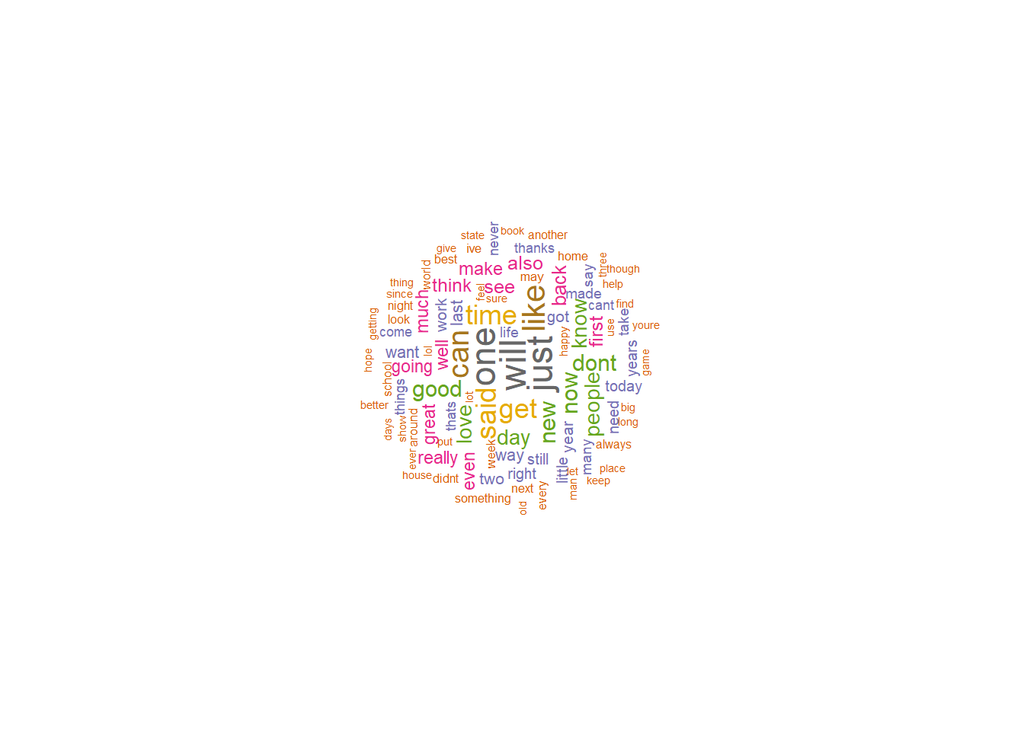

```r
wordcl<-names(csd_sort[1:200])
freqcl<-csd_sort[1:200]
datawcl<-data.frame(wordcl,freqcl, stringsAsFactors = FALSE)
wordcloud(words = datawcl$wordcl, freq = datawcl$freqcl, min.freq = 1, max.words=100, random.order=FALSE, rot.per=0.35,colors=brewer.pal(8, "Dark2"),scale=c(1.5,0.22))
```

In order to determine the number of unique words needed in a frequency sorted dictionary to cover 50% or 90% of all word instances in the language, i have used the “cumsum” function that calculates a cumaltive sum of a list.

```r
ans<-cumsum(csd_sort)/sum(csd_sort)
ans_fin<-c(ans, use.names=FALSE)
which(ans_fin>=0.5 & ans_fin<=0.5001)
```

```
## [1] 963
```

```r
which(ans_fin>=0.9 & ans_fin<=0.900005)
```

```
## [1] 15996
```

It can be observed that for covering 50% of the word instances, 963 words are enough. On the other hand for 90% of all the word instances, 15,996 words are needed.  
In order to detect the words that are from a foreign language, an online dictionary could be used to determine the words that are outside the list of the words belonging to the english language. One obvious way to increase the coverage is to increase the number of unique words used But it could also be achieved by performing lemmatization or stemming. These techniques reduce word variations to simpler forms that may help increase the coverage of NLP algorithm. As the dataset here is too large, i haven’t performed lemmatization or stemming.

### My Approach

I plan to first build a simple **3-gram model** to predict the next word. I plan to take into consideration the RAM used up and the time of my algorithm in order to come up with the **an optimal model**.